# Assessment 1.2

"Divya Kasturi s4654177

22/05/2021

#Data Wrangling #created an r chunk to install package skimr and read the packages tidyverse and skimr

```r
#install.packages('skimr')
library(tidyverse)
library(skimr)
```

#a variable fastfood is used (as created in assessment1.1) to read the dataset fastfood.

```r
fastfood<-read.csv("https://raw.githubusercontent.com/rfordatascience/tidytuesday/master/data/2018/2018-09-04/fastfood_calories.csv")
```

#used skim function to display the types of variables in the dataset.

```r
fastfood%>%skim()
```

Data summary

| Name | Piped data |
| --- | --- |
| Number of rows | 515 |
| Number of columns | 18 |
| _______________________ |  |
| Column type frequency: |  |
| character | 3 |
| numeric | 15 |
| ________________________ |  |
| Group variables | None |

**Variable type: character**

| skim_variable | n_missing | complete_rate | min | max | empty | n_unique | whitespace |
| --- | --- | --- | --- | --- | --- | --- | --- |
| restaurant | 0 | 1 | 5 | 11 | 0 | 8 | 0 |
| item | 0 | 1 | 5 | 63 | 0 | 505 | 0 |
| salad | 0 | 1 | 5 | 5 | 0 | 1 | 0 |

**Variable type: numeric**

| skim_variable | n_missing | complete_rate | mean | sd | p0 | p25 | p50 | p75 | p100 | hist |
| --- | --- | --- | --- | --- | --- | --- | --- | --- | --- | --- |
| X | 0 | 1.00 | 258.00 | 148.81 | 1 | 129.5 | 258.0 | 386.5 | 515 | ▇▇▇▇▇ |
| calories | 0 | 1.00 | 530.91 | 282.44 | 20 | 330.0 | 490.0 | 690.0 | 2430 | ▇▆▁▁▁ |
| cal_fat | 0 | 1.00 | 238.81 | 166.41 | 0 | 120.0 | 210.0 | 310.0 | 1270 | ▇▃▁▁▁ |
| total_fat | 0 | 1.00 | 26.59 | 18.41 | 0 | 14.0 | 23.0 | 35.0 | 141 | ▇▃▁▁▁ |
| sat_fat | 0 | 1.00 | 8.15 | 6.42 | 0 | 4.0 | 7.0 | 11.0 | 47 | ▇▃▁▁▁ |
| trans_fat | 0 | 1.00 | 0.47 | 0.84 | 0 | 0.0 | 0.0 | 1.0 | 8 | ▇▁▁▁▁ |
| cholesterol | 0 | 1.00 | 72.46 | 63.16 | 0 | 35.0 | 60.0 | 95.0 | 805 | ▇▁▁▁▁ |
| sodium | 0 | 1.00 | 1246.74 | 689.95 | 15 | 800.0 | 1110.0 | 1550.0 | 6080 | ▇▆▁▁▁ |
| total_carb | 0 | 1.00 | 45.66 | 24.88 | 0 | 28.5 | 44.0 | 57.0 | 156 | ▅▇▂▁▁ |
| fiber | 12 | 0.98 | 4.14 | 3.04 | 0 | 2.0 | 3.0 | 5.0 | 17 | ▇▅▂▁▁ |
| sugar | 0 | 1.00 | 7.26 | 6.76 | 0 | 3.0 | 6.0 | 9.0 | 87 | ▇▁▁▁▁ |
| protein | 1 | 1.00 | 27.89 | 17.68 | 1 | 16.0 | 24.5 | 36.0 | 186 | ▇▂▁▁▁ |
| vit_a | 214 | 0.58 | 18.86 | 31.38 | 0 | 4.0 | 10.0 | 20.0 | 180 | ▇▁▁▁▁ |
| vit_c | 210 | 0.59 | 20.17 | 30.59 | 0 | 4.0 | 10.0 | 30.0 | 400 | ▇▁▁▁▁ |
| calcium | 210 | 0.59 | 24.85 | 25.52 | 0 | 8.0 | 20.0 | 30.0 | 290 | ▇▁▁▁▁ |

#displayed the number of observations for each restaurant

```r
fastfood%>%count(restaurant)
```

```
##    restaurant   n
## 1       Arbys  55
## 2 Burger King  70
## 3 Chick Fil-A  27
## 4 Dairy Queen  42
## 5   Mcdonalds  57
## 6       Sonic  53
## 7      Subway  96
## 8   Taco Bell 115
```

#Calculated and displayed the average number of calories for each restaurant.

```r
fastfood%>%
  group_by(restaurant)%>%
  summarise(average_calories=mean(calories))%>%
  ungroup()
```

```
## # A tibble: 8 x 2
##   restaurant  average_calories
##   <chr>                  <dbl>
## 1 Arbys                   533.
## 2 Burger King             609.
## 3 Chick Fil-A             384.
## 4 Dairy Queen             520.
## 5 Mcdonalds               640.
## 6 Sonic                   632.
## 7 Subway                  503.
## 8 Taco Bell               444.
```

#Created a variable to the dataset, which calculates the average calories per type of restaurant and call it `average_calories`

```r
fastfood%>%
  group_by(restaurant)%>%
  mutate(average_calories=mean(calories))%>%
  ungroup()
```

```
## # A tibble: 515 x 19
##        X restaurant item            calories cal_fat total_fat sat_fat trans_fat
##    <int> <chr>      <chr>              <int>   <int>     <int>   <dbl>     <dbl>
##  1     1 Mcdonalds  Artisan Grille~      380      60         7       2       0
##  2     2 Mcdonalds  Single Bacon S~      840     410        45      17       1.5
##  3     3 Mcdonalds  Double Bacon S~     1130     600        67      27       3
##  4     4 Mcdonalds  Grilled Bacon ~      750     280        31      10       0.5
##  5     5 Mcdonalds  Crispy Bacon S~      920     410        45      12       0.5
##  6     6 Mcdonalds  Big Mac              540     250        28      10       1
##  7     7 Mcdonalds  Cheeseburger         300     100        12       5       0.5
##  8     8 Mcdonalds  Classic Chicke~      510     210        24       4       0
##  9     9 Mcdonalds  Double Cheeseb~      430     190        21      11       1
## 10    10 Mcdonalds  Double Quarter~      770     400        45      21       2.5
## # ... with 505 more rows, and 11 more variables: cholesterol <int>,
## #   sodium <int>, total_carb <int>, fiber <int>, sugar <int>, protein <int>,
## #   vit_a <int>, vit_c <int>, calcium <int>, salad <chr>,
## #   average_calories <dbl>
```

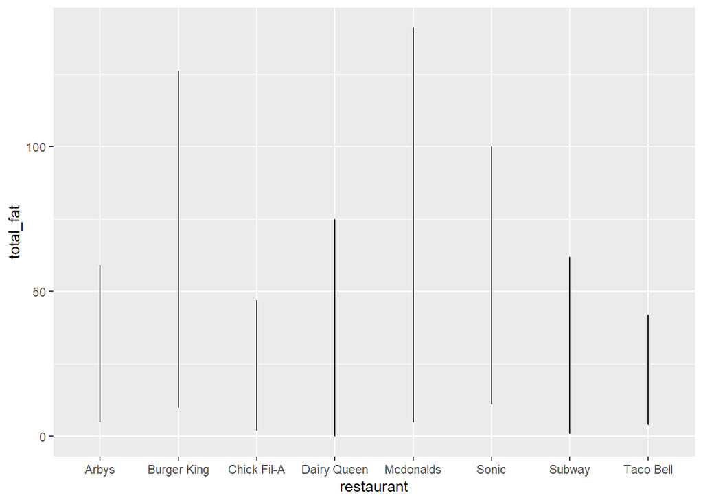

```r
fastfood%>%
  ggplot(aes(restaurant,total_fat))+
  geom_line()
```

# Displayed the count of observations per each type of restaurant.

```r
fastfood%>%count(restaurant)
```

```
##    restaurant   n
## 1       Arbys  55
## 2 Burger King  70
## 3 Chick Fil-A  27
## 4 Dairy Queen  42
## 5   Mcdonalds  57
## 6       Sonic  53
## 7      Subway  96
## 8   Taco Bell 115
```

#Added a variable to the dataset and calculated the maximum total fat per type of restaurant and call it `max_total_fat`

```r
fastfood%>%
  group_by(restaurant)%>%
  mutate(max_total_fat=max(total_fat))%>%
  ungroup()
```

```
## # A tibble: 515 x 19
##        X restaurant item            calories cal_fat total_fat sat_fat trans_fat
##    <int> <chr>      <chr>              <int>   <int>     <int>   <dbl>     <dbl>
##  1     1 Mcdonalds  Artisan Grille~      380      60         7       2       0
##  2     2 Mcdonalds  Single Bacon S~      840     410        45      17       1.5
##  3     3 Mcdonalds  Double Bacon S~     1130     600        67      27       3
##  4     4 Mcdonalds  Grilled Bacon ~      750     280        31      10       0.5
##  5     5 Mcdonalds  Crispy Bacon S~      920     410        45      12       0.5
##  6     6 Mcdonalds  Big Mac              540     250        28      10       1
##  7     7 Mcdonalds  Cheeseburger         300     100        12       5       0.5
##  8     8 Mcdonalds  Classic Chicke~      510     210        24       4       0
##  9     9 Mcdonalds  Double Cheeseb~      430     190        21      11       1
## 10    10 Mcdonalds  Double Quarter~      770     400        45      21       2.5
## # ... with 505 more rows, and 11 more variables: cholesterol <int>,
## #   sodium <int>, total_carb <int>, fiber <int>, sugar <int>, protein <int>,
## #   vit_a <int>, vit_c <int>, calcium <int>, salad <chr>, max_total_fat <int>
```

#Used observations for Mcdonalds to plot sugar variable against protein with `geom_point()`

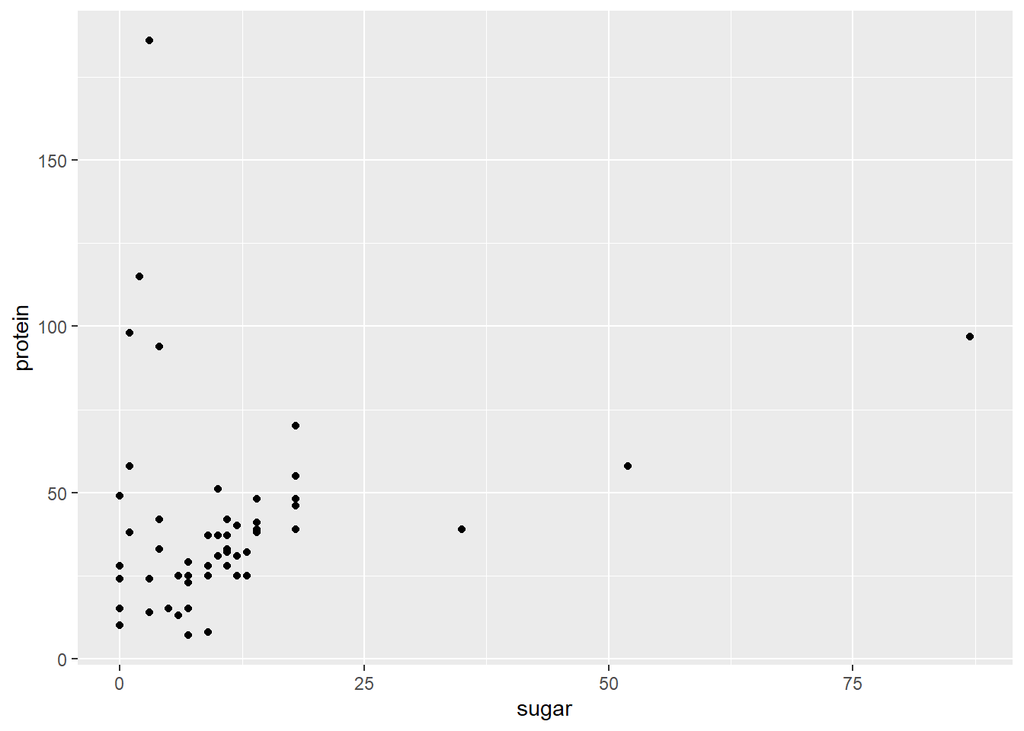

```r
fastfood%>%
  filter(restaurant=="Mcdonalds")%>%
  ggplot(aes(sugar,protein))+
  geom_point()
```